# Posterior predictive checking: Stochastic learning in dogs

- Show All Code
- Hide All Code
- View Source

Author

Aki Vehtari and Andrew Gelman

Published

2024-04-20

Modified

2026-08-20

This notebook includes the `brms` code for the Bayesian Workflow book Chapter 21 *Posterior predictive checking: Stochastic learning in dogs*.

# 1 Introduction

This notebook is a remake of the Andrew Gelman’s analysis of stochastic learning in dogs data by Bush and Mosteller (1955). Andrew wrote his models in [Stan language](https://mc-stan.org/), and here we use [`brms`](https://paul-buerkner.github.io/brms/) and add some further diagnostics.

**Load packages**

```r
library(rprojroot)
root <- has_file(".Bayesian-Workflow-root")$make_fix_file()
library(ggplot2)
library(bayesplot)
theme_set(bayesplot::theme_default(base_family = "sans", base_size = 16))
library(patchwork)
library(tidybayes)
library(RColorBrewer)
library(priorsense)
# requires loo 2.10.0 or later
library(loo)
library(posterior)
library(brms)
options(brms.backend = "cmdstanr")
options(mc.cores = 4)
library(dplyr)
library(tibble)
library(matrixStats)
library(tinytable)
options(
  tinytable_format_num_fmt = "significant_cell",
  tinytable_format_digits = 2,
  tinytable_tt_digits = 2
)
library(reliabilitydiag)
library(Iso)
library(assertthat)
```

# 2 Data

Data comes originally from a book by Bush and Mosteller (1955). The data come from 30 dogs in a stochastic learning experiment. Each dog was put in a cage where it would be shocked if it did not jump out in time, a few seconds after a light goes on (we do not advocate giving shocks to dogs). After 25 tries, all of the dogs learned to jump and avoid the shock. Bush and Mosteller then posited a two-parameter model which allowed different amounts of learning from shocks and avoidances:
$$\Pr(\mathrm{shock}) = a^\mathrm{(\# \ of \ previous \ shocks)}\,
b^\mathrm{(\# \ of \ previous \ avoidances)}$$
Under this model, the probability of being shocked starts at 1, which is appropriate, as there is no reason the dogs should know at the start that the light would precede a shock, and indeed any dogs that jumped before the first trial were excluded from the experiment. From then on, as long as the parameters $a$ and $b$ are between 0 and 1, the probability of shock gradually declines over time.

```r
dogs <- read.table(root("dogs", "data", "dogs.dat"), skip = 2)
shock <- ifelse(as.matrix(dogs[, 2:26]) == "S", 1, 0)
```

We create a data frame

```r
dogs_df <- data.frame(
        shock = as.numeric(shock),
        dog = rep(1:nrow(shock), times = ncol(shock)),
        time = rep(1:ncol(shock), each = nrow(shock)))
```

The original data includes the first event which is always shock, and as there is no uncertainty about that event, it can be removed from the data without any loss of information.

```r
dogs_df <- dogs_df |> dplyr::filter(time > 1)
```

Add the number of previous shocks and avoidances as covariates

```r
dogs_df$prev_shock <- as.numeric(rowCumsums(shock)[, 1:(ncol(shock) - 1)])
dogs_df$prev_avoid <- as.numeric(rowCumsums(1 - shock)[, 1:(ncol(shock) - 1)])
```

# 3 Model 0: Logistic regression

We start with a simple logistic regression model
$$\Pr(\mathrm{shock}) = {\mathrm{logit}^{-1}(\alpha + \beta t)}$$
where $t$ denotes time. By default, `brms` assigns $\mathrm{Student}_3(0, 2.5)$ prior on intercept $\alpha$, and we add $\mathrm{normal}(0, 1)$ prior on coefficent $\beta$,
$$\begin{aligned}
\alpha & \sim \mathrm{Student}_3(0, 2.5)\\
\beta & \sim \mathrm{normal}(0, 1).
\end{aligned}$$

```r
bfit_0 <- brm(shock ~ time, family = bernoulli(),
              prior = prior(normal(0,1)),
              data = dogs_df, refresh = 0)
bfit_0 <- add_criterion(bfit_0, criterion = "loo")
```

# 4 Model 0h: Hierarchical logistic regression

Instead of doing model checking for the simple logistic regression, we build a hierarchical model so that each dog has their own parameters. We number this as 0h, so that the rest of model numbers follow Andrew’s numbering.

$$\Pr(\mathrm{shock}) = {\mathrm{logit}^{-1}(\alpha_j + \beta_j t)},$$
where $\alpha_j$ and $\beta_j$ are the parameters for dog $j$. `brms` uses following default priors, except we added the weakly informative normal prior for $\beta_0$.
$$\begin{aligned}
\left(\begin{array}{c}\alpha_j \\ \beta_j\end{array} \right) & \sim \mathrm{MVN}(\mu_{\alpha,\beta}, \Sigma_{\alpha,\beta})\\
\mu_{\alpha} & \sim \mathrm{Student}_3(0, 2.5)\\
\mu_{\beta} & \sim \mathrm{normal}(0, 1)\\
\Sigma_{\alpha,\beta} & = \left(\begin{array}{cc}\sigma_\alpha & 0 \\ 0 & \sigma_\beta\end{array}\right) Q_{\alpha,\beta} \left(\begin{array}{cc}\sigma_\alpha & 0 \\ 0 & \sigma_\beta\end{array}\right) \\
\sigma_\alpha,\sigma_\beta & \sim \mathrm{Student}^{+}_3(0, 2.5) \\
Q_{\alpha,\beta} & \sim \mathrm{LKJ}(1).
\end{aligned}$$

```r
bfit_0h <- brm(shock ~ time + (time | dog), family = bernoulli(),
               prior = prior(normal(0,1)),
               data = dogs_df, refresh = 0, adapt_delta = 0.95)
bfit_0h <- add_criterion(bfit_0h, criterion = "loo", save_psis = TRUE)
```

## 4.1 Model comparison

We compare the simple and hierarchical logistic regression using PSIS-LOO-CV (Vehtari, Gelman, and Gabry 2017), and as the latter is clearly better, we can skip model checking for the simpler model.

```r
loo_compare(bfit_0, bfit_0h) |>
  select(model, elpd_diff, se_diff, p_worse, diag_diff, diag_elpd) |>
  tt() |>
  format_tt(j=4, replace = "-")
```

| model | elpd_diff | se_diff | p_worse | diag_diff | diag_elpd |
| --- | --- | --- | --- | --- | --- |
| bfit_0h | 0 | 0 | - |  |  |
| bfit_0 | -13 | 5.7 | 0.99 |  |  |

## 4.2 Visualize predictions

Visualize the model fit for 9 first dogs with some help from `tidybayes` (Kay 2023).

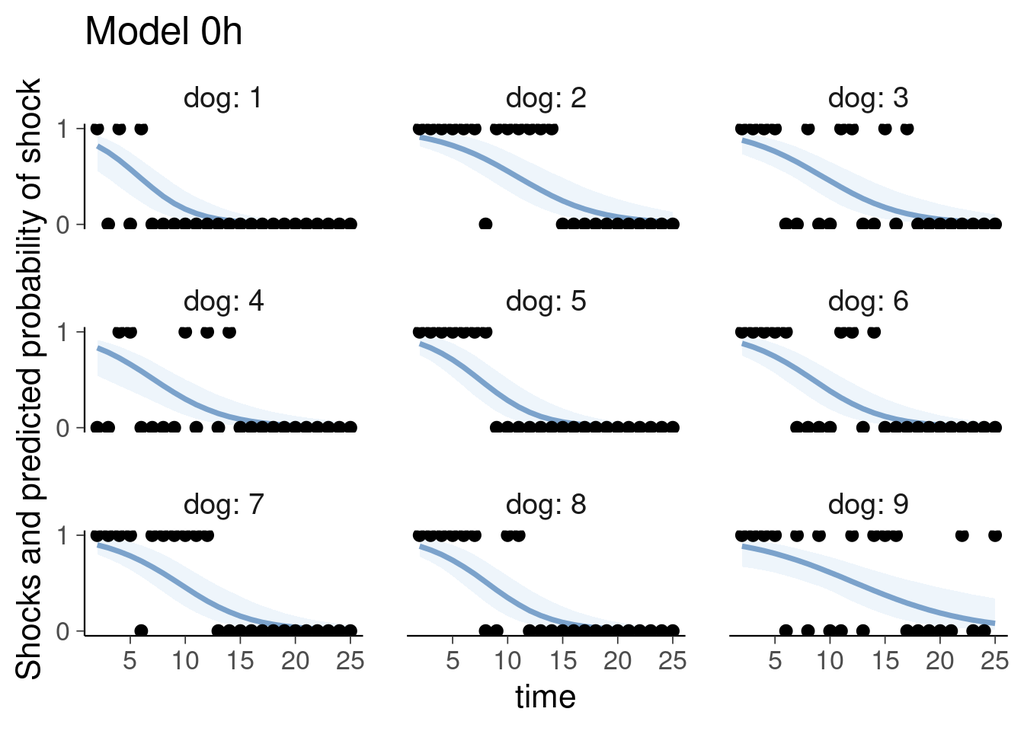

Figure 1

```r
plot_pred9_0h <- dogs_df |>
  dplyr::filter(dog <= 9) |>
        add_linpred_draws(bfit_0h, transform = TRUE) |>
        ggplot(aes(x = time, y = .linpred)) +
        stat_lineribbon(.width = c(.95), alpha = 1 / 2, color = brewer.pal(5, "Blues")[[5]]) +
  scale_fill_brewer() +
  geom_point(data = dplyr::filter(dogs_df, dog<=9), aes(x = time, y = shock, group = dog)) +
  facet_wrap( ~ dog, labeller = label_both) +
  scale_y_continuous(breaks = c(0, 1)) +
  theme(legend.position = "none") +
  labs(y = "Shocks and predicted probability of shock", title="Model 0h")
plot_pred9_0h
```

## 4.3 Predictive calibration check

Examine how well the leave-one-out predictive probabilities (computed with `loo_epred()`) are calibrated using PAV-adjusted calibration plot (Dimitriadis, Gneiting, and Jordan 2021) implemented in `reliabilitydiag`. Looks quite good.

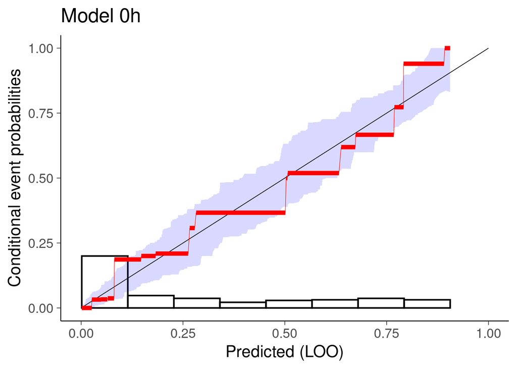

Figure 2

```r
rd <- reliabilitydiag(EMOS = loo_epred(bfit_0h), y = dogs_df$shock)
plot_calib_0h <- autoplot(rd) +
        labs(
                x = "Predicted (LOO)",
                y = "Conditional event probabilities",
                title = "Model 0h"
        ) +
  bayesplot::theme_default(base_family = "sans", base_size = 16)
plot_calib_0h
```

## 4.4 Residual plots

When can use PAV-adjustment to make also residual plots with respect to covariates (details in forthcoming paper).

```r
ppc_pava_residual <-
  function(y,
           epred,
           x = NULL,
           prob = .9,
           n.boot = 1000,
           interval_geom = "ribbon",
           alpha = .2,
           ...) {
    require("Iso")
    require("ggplot2")
    assertthat::assert_that(is.numeric(y))
    assertthat::assert_that(is.numeric(epred))
    assertthat::are_equal(length(epred), length(y))
    # Compute predictive means and their ordering.
    yrep_bar_order <- order(epred)

    # If no x value supplied, plot residuals against predictive means.
      if (is.null(x)) {
        x <- epred
      }

      cep_df <- seq_len(n.boot) |>
        lapply(\(i) data.frame(cep = Iso::pava(rbinom(
          length(y), 1, epred
        )[yrep_bar_order]),
        id_ = yrep_bar_order)) |>
        dplyr::bind_rows() |>
        dplyr::group_by(id_) |>
        dplyr::summarise(upper = quantile(cep, .5 + .5 * prob),
                         lower = quantile(cep, .5 * (1 - prob)))
      cep_df$yrep_bar <- epred
      cep_df[yrep_bar_order, "cep"] <- Iso::pava(y[yrep_bar_order])
    cep_df$x <- x
    cep_df$ymax <- cep_df$upper - cep_df$yrep_bar
    cep_df$ymin <- cep_df$lower - cep_df$yrep_bar
    bw <- .5 * bw.SJ(cep_df$x)
    w <- sapply(cep_df$x, \(x_i) dnorm(cep_df$x, x_i, bw))
    cep_df$ymaxs <- (t(w) %*% cep_df$ymax) / colSums(w)
    cep_df$ymins <- (t(w) %*% cep_df$ymin) / colSums(w)

    ggplot(cep_df,
           aes(
             y = cep - yrep_bar,
             ymax = ymaxs,
             ymin = ymins,
             x = x
           )) +
      geom_hline(yintercept=0, alpha=0.3) +
      stat_identity(aes(
        colour = TRUE,
        fill = TRUE
      ),
      alpha = alpha,
      geom = interval_geom,
      ...) +
      geom_point(aes(colour = (cep >= lower) & (cep <= upper))) +
      scale_colour_discrete(aesthetics = c("fill" , "colour")) +
      theme(legend.position = "none") +
      labs(y = "PAVA Residual")
  }
```

PAV-adjusted residual plot looks reasonable.

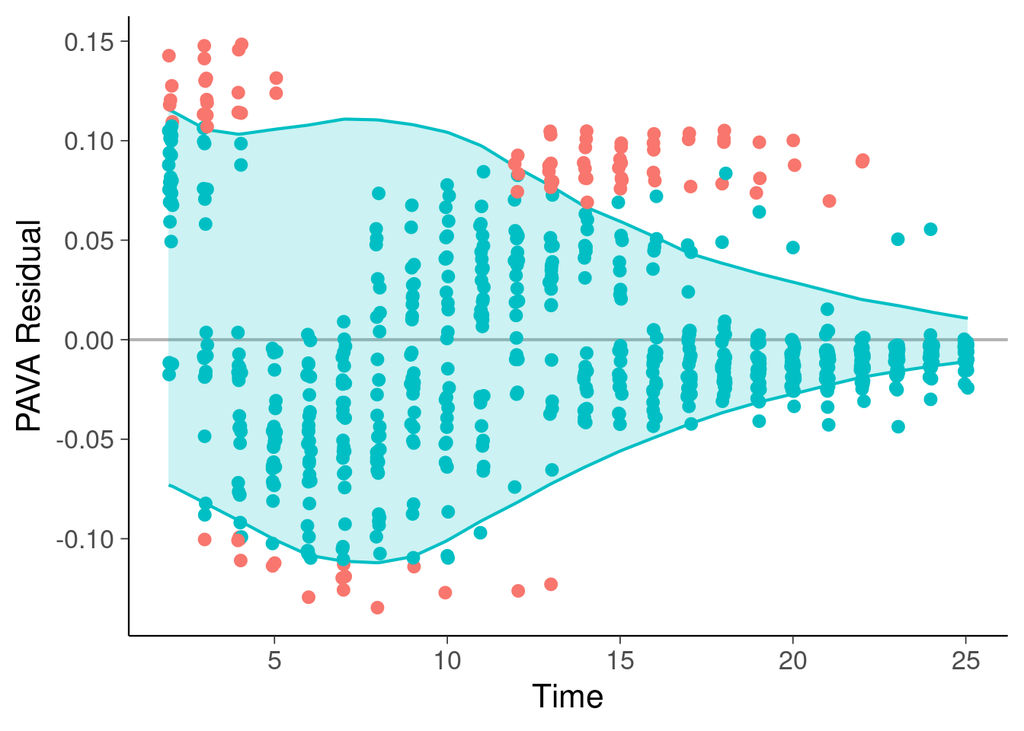

Figure 3

```r
ppc_pava_residual(dogs_df$shock,
                  loo_epred(bfit_0h),
                  jitter(dogs_df$time,0.3)) +
  labs(x = "Time")
```

## 4.5 Posterior predictive checking

Visual posterior predictive checking plotting predicted shocks and avoidances by ordering the dogs with last observed shock.

```r
pred_logit <- function(fit) {
  matrix(c(rep(1, 30),
           posterior_predict(fit, ndraws = 1) |>
             as.numeric()), nrow = 30, ncol = 25)
}
ppc_shocks <- function(shock, title) {
  expand.grid(dog = rev(1:30), time = 1:25) |>
    mutate(shock = as.numeric(shock[order(apply(shock, 1, \(x) max(which(x == 1)))), ])) |>
  ggplot(aes(time, dog, fill = shock)) +
  geom_tile() +
  ## coord_fixed() +
  scale_fill_gradient(low = "#ffffc8", high = "#7c0025") +
  theme(legend.position = "none",
        axis.line = element_blank(),
        axis.text = element_blank(),
        axis.ticks = element_blank(),
        axis.title.x = element_blank(),
        axis.title.y = element_text(angle = 0, vjust = 0.6)) +
    labs(y = title)
}
```

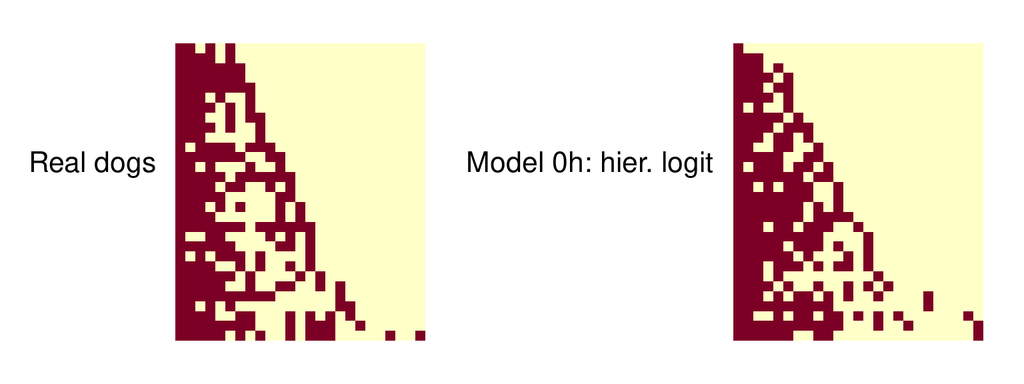

Figure 4

```r
ppc_shocks(shock, "Real dogs") +
  ppc_shocks(pred_logit(bfit_0h), "Model 0h: hier. logit")
```

Posterior predictive checking using mean number of switches between shocks and avoidances as the test statistic.

```r
mean_switches <- function(shock) {
  shock |> rowDiffs() |> abs() |> rowSums() |> mean()
}
yrep <- replicate(100, mean_switches(pred_logit(bfit_0h)))
```

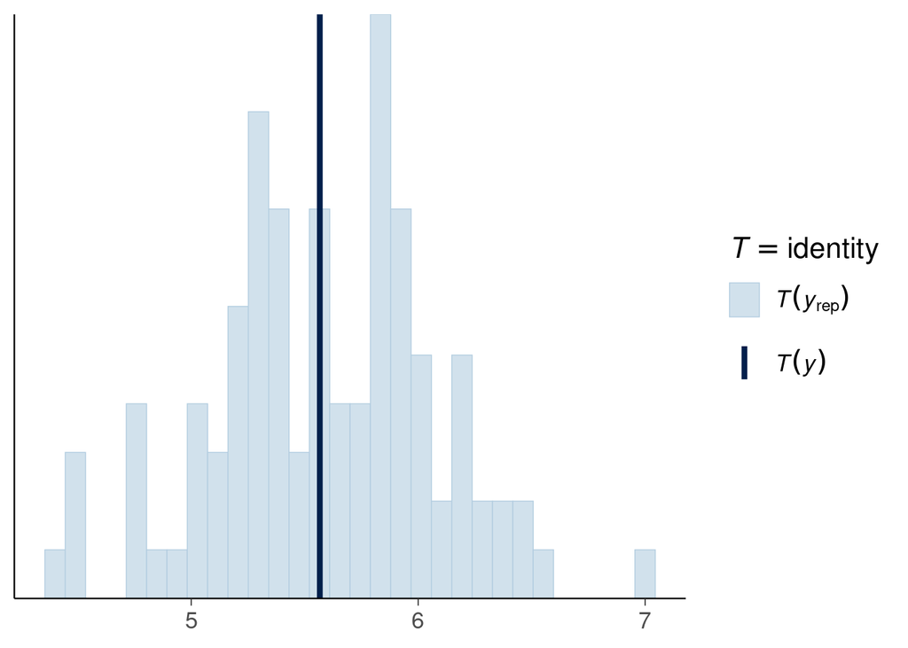

Figure 5

```r
ppc_stat(mean_switches(shock), matrix(yrep, nrow=length(yrep)), stat="identity")
```

## 4.6 Prior-likelihood sensitivity analysis

Using `priorsense` package for powerscaling prior-likelihood sensitivity analysis (Kallioinen et al. 2023) shows that the data are informative and there is no need to think more about priors unless we do happen to have easily available strong prior information.

```r
powerscale_sensitivity(bfit_0h, variable = variables(as_draws(bfit_0h))[1:6]) |>
        tt() |>
        format_tt(num_fmt = "decimal")
```

| variable | prior | likelihood | diagnosis |
| --- | --- | --- | --- |
| b_Intercept | 0.01 | 0.18 | - |
| b_time | 0.02 | 0.24 | - |
| sd_dog__Intercept | 0.02 | 0.59 | - |
| sd_dog__time | 0.02 | 0.46 | - |
| cor_dog__Intercept__time | 0.01 | 0.35 | - |
| Intercept | 0.02 | 0.17 | - |

# 5 Model 1: 1-parameter log model

```r
bfit_1 <- brm(bf(shock ~ a^(time - 1), a ~ 1, nl = TRUE),
              family = bernoulli(link = "identity"),
              prior = prior(beta(1, 1), nlpar = "a", lb = 0, ub = 1),
              data = dogs_df, refresh = 0)
bfit_1 <- add_criterion(bfit_1, criterion = "loo")
```

## 5.1 Model comparison

PSIS-LOO-CV comparison shows that the 1-parameter log model is worse than either logistic regression model. Thus we don’t examine it further and move to more elaborate log models.

```r
loo_compare(bfit_0, bfit_0h, bfit_1) |>
  select(model, elpd_diff, se_diff, p_worse, diag_diff, diag_elpd) |>
  tt() |>
  format_tt(j=4, replace = "-")
```

| model | elpd_diff | se_diff | p_worse | diag_diff | diag_elpd |
| --- | --- | --- | --- | --- | --- |
| bfit_0h | 0 | 0 | - |  |  |
| bfit_0 | -13 | 5.7 | 0.99 |  |  |
| bfit_1 | -16 | 5.8 | 1 |  |  |

# 6 Model 2: 2-parameter log model

This is the original 2-parameter model proposed by Bush and Mosteller (1955):
$$\begin{aligned}
\Pr(\mathrm{shock}) & = a^{x_{1jt}}\,b^{x_{2jt}}\\
a,b & \sim \mathrm{uniform}(0,1),
\end{aligned}$$
where $x_{1jt}$ and $x_{1jt}$ are the number of previous shocks and avoidances, respectively, in trials $1,\ldots,t-1$ for dog $j$.

```r
bfit_2 <- brm(bf(shock ~ a^prev_shock * b^prev_avoid,
                a ~ 1, b ~ 1, nl = TRUE),
              family = bernoulli(link = "identity"),
              prior = c(prior(beta(1, 1), nlpar = "a", lb = 0, ub = 1),
                        prior(beta(1, 1), nlpar = "b", lb = 0, ub = 1)),
              data = dogs_df, refresh=0)
bfit_2 <- add_criterion(bfit_2, criterion = "loo")
```

## 6.1 Model comparison

PSIS-LOO-CV comparison shows that the 2-parameter log model is worse than the hierarchical logistic regression model, but not significantly. We don’t examine this model further, as we can make the comparison more fair by using hierarchical 2-parameter log model.

```r
loo_compare(bfit_0h, bfit_2) |>
  select(model, elpd_diff, se_diff, p_worse, diag_diff, diag_elpd) |>
  tt() |>
  format_tt(j=4, replace = "-")
```

| model | elpd_diff | se_diff | p_worse | diag_diff | diag_elpd |
| --- | --- | --- | --- | --- | --- |
| bfit_0h | 0 | 0 | - |  |  |
| bfit_2 | -4.7 | 4.3 | 0.86 |  |  |

# 7 Model 3: hierarchical 1-parameter log model

We could go directly to hierarchical 2-parameter log model, but for completeness compared to Andrew’s analysis, we include hierarchical 1-parameter log model, too. Each dog has now it’s own parameter $a_j$ with a normal hierarchical prior on $\mathrm{logit}(a_j)$.
$$\begin{aligned}
\Pr(\mathrm{shock}) & = a_j^{(t - 1)}\\
\mathrm{logit}(a_j) & \sim \mathrm{normal}(\mu_{\mathrm{logit}(a)}, \sigma_{\mathrm{logit}(a)})\\
\mu_{\mathrm{logit}(a)} & \sim \mathrm{Student}_3(0, 2.5)\\
\sigma_{\mathrm{logit}(a)} & \sim \mathrm{Student}^{+}_3(0, 2.5)
\end{aligned}$$
where $a_j$ is parameter for dog $j$.

```r
inv_logit <- function(x) 1 / (1 + exp(-x))
bfit_3 <- brm(bf(shock ~ inv_logit(etaa)^(time - 1),
                 etaa ~ (1 | dog), nl = TRUE),
              family = bernoulli(link = "identity"),
              prior = prior(student_t(3, 0, 2.5), nlpar = "etaa"),
              data = dogs_df, refresh = 0)
bfit_3 <- add_criterion(bfit_3, criterion = "loo")
```

## 7.1 Model comparison

PSIS-LOO-CV comparison shows that the hierarchical 1-parameter log model is worse than the hierarchcial logistic regression model and non-hierarchcial 2-parameter log model, and thus we don’t examine this model further.

```r
loo_compare(bfit_0h, bfit_2, bfit_3) |>
  select(model, elpd_diff, se_diff, p_worse, diag_diff, diag_elpd) |>
  tt() |>
  format_tt(j=4, replace = "-")
```

| model | elpd_diff | se_diff | p_worse | diag_diff | diag_elpd |
| --- | --- | --- | --- | --- | --- |
| bfit_0h | 0 | 0 | - |  |  |
| bfit_2 | -4.7 | 4.3 | 0.86 |  |  |
| bfit_3 | -9.1 | 4.3 | 0.98 |  |  |

# 8 Model 4: hierarchical 2-parameter log model

Each dog has now it’s own parameters $a_j$ and $b_j$ with a multivariate normal hierarchical prior.
$$\begin{aligned}
\Pr(\mathrm{shock}) & = a_j^{x_{1jt}}\,b_j^{x_{2jt}}\\
\left(\begin{array}{c}\mathrm{logit}(a)_j \\ \mathrm{logit}(b)_j\end{array} \right) & \sim \mathrm{MVN}(\mu_{\mathrm{logit}(a),\mathrm{logit}(b)}, \Sigma_{\mathrm{logit}(a),\mathrm{logit}(b)})\\
\mu_{\mathrm{logit}(a)}, \mu_{\mathrm{logit}(b)} & \sim \mathrm{Student}_3(0, 2.5)\\
\Sigma_{\mathrm{logit}(a),\mathrm{logit}(b)} & = \left(\begin{array}{cc}\sigma_\mathrm{logit}(a) & 0 \\ 0 & \sigma_\mathrm{logit}(b)\end{array}\right) Q_{\mathrm{logit}(a),\mathrm{logit}(b)} \left(\begin{array}{cc}\sigma_\mathrm{logit}(a) & 0 \\ 0 & \sigma_\mathrm{logit}(b)\end{array}\right) \\
\sigma_{\mathrm{logit}(a)}, \sigma_{\mathrm{logit}(b)} & \sim \mathrm{Student}^{+}_3(0, 2.5)\\
Q_{\mathrm{logit}(a),\mathrm{logit}(b)} & \sim \mathrm{LKJ}(1).
\end{aligned}$$

```r
bfit_4 <- brm(bf(shock ~ inv_logit(etaa)^prev_shock * inv_logit(etab)^prev_avoid,
                 mvbind(etaa, etab) ~ (1 |p| dog), nl=TRUE),
              family = bernoulli(link = "identity"),
              prior = c(prior(student_t(3, 0, 2.5), nlpar = "etaa"),
                        prior(student_t(3, 0, 2.5), nlpar = "etab")),
              data = dogs_df, refresh = 0)
bfit_4 <- add_criterion(bfit_4, criterion = "loo", save_psis = TRUE)
```

## 8.1 Model comparison

PSIS-LOO-CV comparison shows that hierarchical 2-parameter log model is worse than the hierarchical logistic regression, although not significantly. While adding hierarchy to logistic regression improved the predictive performance significantly, adding hierarchy to 2-parameter log model has a very small effect. This is probably due to the fact that the 2-parameter log model was already able to take into account the variation in the shock and avoidances by using them as covariates.

```r
loo_compare(bfit_0h, bfit_2, bfit_4) |>
  select(model, elpd_diff, se_diff, p_worse, diag_diff, diag_elpd) |>
  tt() |>
  format_tt(j=4, replace = "-")
```

| model | elpd_diff | se_diff | p_worse | diag_diff | diag_elpd |
| --- | --- | --- | --- | --- | --- |
| bfit_0h | 0 | 0 | - |  |  |
| bfit_4 | -3.8 | 3.1 | 0.89 | \|elpd_diff\| < 4 |  |
| bfit_2 | -4.7 | 4.3 | 0.86 |  |  |

## 8.2 Visualize predictions

Visualize the model fit for 9 first dogs. These look different from the logistic regression. Specifically we tend to see a sharper drop after the first avoidance, which makes sense as the magnitude of drop in probability after repeated shocks diminishes, but the first avoidance provides another big drop.

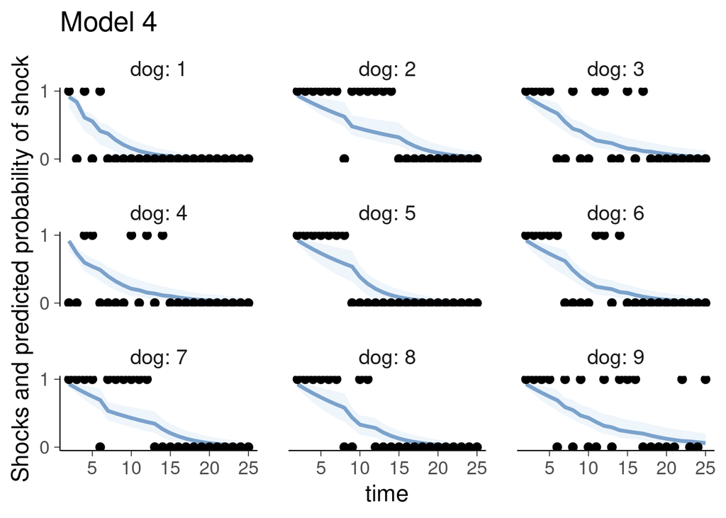

Figure 6

```r
plot_pred9_4 <-dogs_df |>
  dplyr::filter(dog <= 9) |>
        add_linpred_draws(bfit_4, transform = TRUE) |>
        ggplot(aes(x = time, y = .linpred)) +
        stat_lineribbon(.width = c(.95), alpha = 1 / 2,
                        color = brewer.pal(5, "Blues")[[5]]) +
  scale_fill_brewer() +
  geom_point(data = dplyr::filter(dogs_df, dog <= 9),
             aes(x = time, y = shock, group = dog)) +
  facet_wrap( ~ dog, labeller = label_both) +
  theme(legend.position = "none") +
  scale_y_continuous(breaks = c(0, 1)) +
  labs(y = "Shocks and predicted probability of shock", title = "Model 4")
plot_pred9_4
```

We can compare these two the predictions from the non-hierarchial 2-parameter log model, and we can see that even if the model is non-hierarchical, dog-specific number of shocks and avoidances do make the model fit to vary by dog. This can explain why adding hierarchy to the model does not improve the predictive performance.

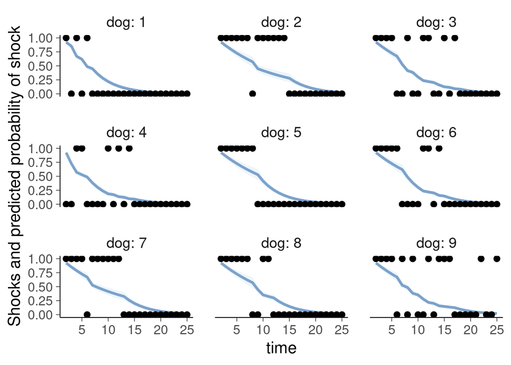

Figure 7

```r
dogs_df |>
  dplyr::filter(dog <= 9) |>
        add_linpred_draws(bfit_2, transform = TRUE) |>
        ggplot(aes(x = time, y = .linpred)) +
        stat_lineribbon(.width = c(.95), alpha = 1 / 2,
                        color = brewer.pal(5, "Blues")[[5]]) +
  scale_fill_brewer() +
  geom_point(data = dplyr::filter(dogs_df, dog<=9),
             aes(x = time, y = shock, group = dog)) +
  facet_wrap( ~ dog, labeller = label_both) +
  theme(legend.position = "none") +
  labs(y = "Shocks and predicted probability of shock")
```

## 8.3 Predictive calibration check

Examine how well the leave-one-out predictive probabilities from hierarchical 2-parameter log model are calibrated. Looks quite good.

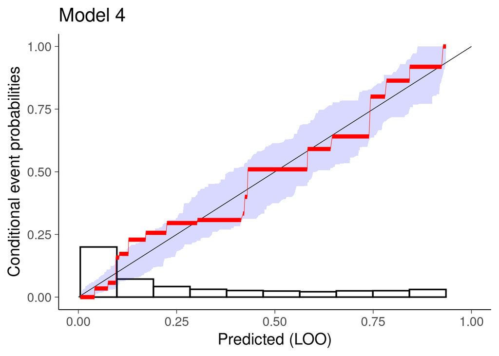

Figure 8

```r
rd <- reliabilitydiag(EMOS = loo_epred(bfit_4), y = dogs_df$shock)
plot_calib_4 <- autoplot(rd) +
  labs(x = "Predicted (LOO)",
       y = "Conditional event probabilities",
       title = "Model 4")+
  bayesplot::theme_default(base_family = "sans", base_size = 16)
plot_calib_4
```

## 8.4 Residual plots

PAV-adjusted residual plot looks reasonable.

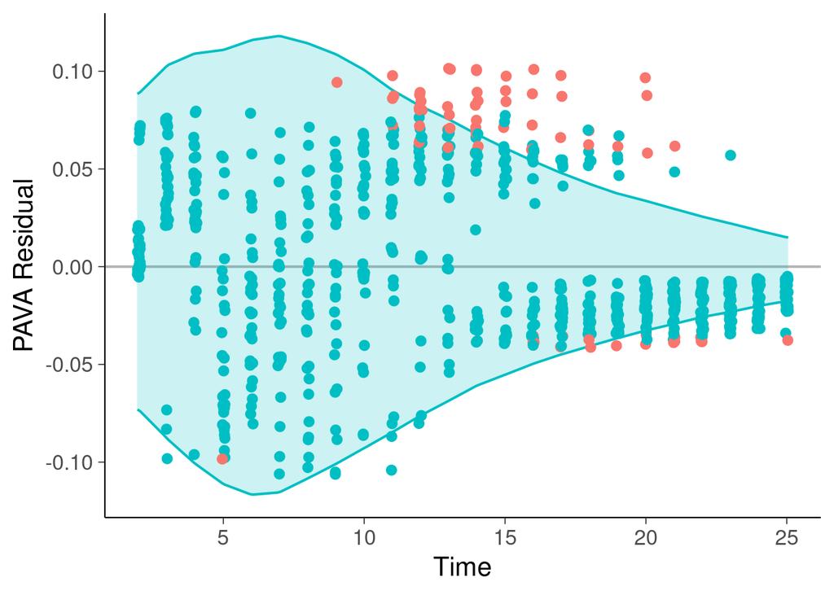

Figure 9

```r
ppc_pava_residual(dogs_df$shock,
                  loo_epred(bfit_4),
                  jitter(dogs_df$time,0.3)) +
  labs(x="Time")
```

## 8.5 Posterior predictive checking

Visual posterior predictive checking

```r
pred_log <- function(fit) {
  pred_shock <- matrix(rep(1, 30), nrow = 30)
  for (t in 2:25) {
    dogs_df_pred <- dplyr::filter(dogs_df, time == t)
    dogs_df_pred$prev_shock <- as.numeric(rowSums(pred_shock))
    dogs_df_pred$prev_avoid <- as.numeric(rowSums(1 - pred_shock))
    pred <- posterior_predict(fit, ndraws = 1, newdata = dogs_df_pred)
    pred_shock <- cbind(pred_shock, as.numeric(pred))
  }
  pred_shock
}
```

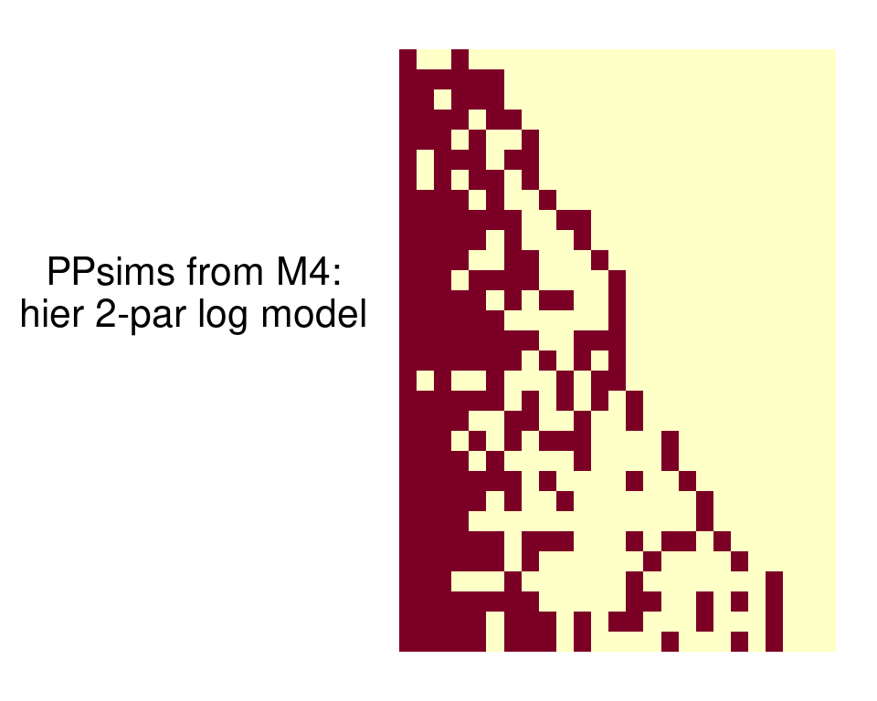

Figure 10

```r
ppc_shocks(pred_log(bfit_4), "PPsims from M4:\nhier 2-par log model")
```

The combined posterior predictive check across models (Figure 21.4 in the book).

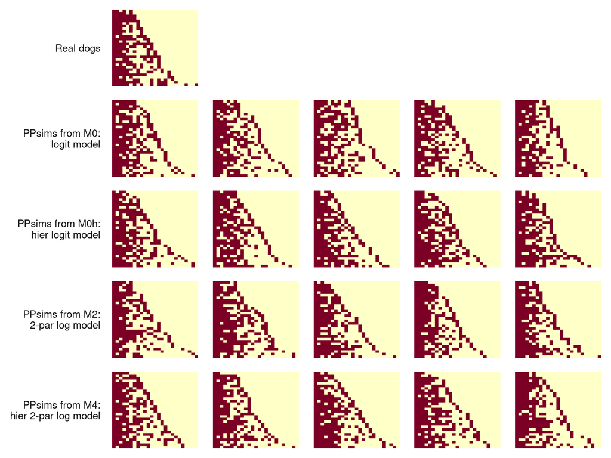

Figure 11

```r
ppc_shocks_df <- function(shock, model, sim) {
  ord <- order(apply(shock, 1, \(x) max(which(x == 1))))
  expand.grid(dog = rev(1:30), time = 1:25) |>
    mutate(shock = as.numeric(shock[ord, ]), model = model, sim = sim)
}
labs_ppc <- c("Real dogs",
              "PPsims from M0:\nlogit model",
              "PPsims from M0h:\nhier logit model",
              "PPsims from M2:\n2-par log model",
              "PPsims from M4:\nhier 2-par log model")
ppc_all <- bind_rows(
  ppc_shocks_df(shock, labs_ppc[1], 1),
  bind_rows(lapply(1:5, \(s) ppc_shocks_df(pred_logit(bfit_0),  labs_ppc[2], s))),
  bind_rows(lapply(1:5, \(s) ppc_shocks_df(pred_logit(bfit_0h), labs_ppc[3], s))),
  bind_rows(lapply(1:5, \(s) ppc_shocks_df(pred_log(bfit_2),    labs_ppc[4], s))),
  bind_rows(lapply(1:5, \(s) ppc_shocks_df(pred_log(bfit_4),    labs_ppc[5], s)))
) |>
  mutate(model = factor(model, levels = labs_ppc))
fig_ppc2 <- ggplot(ppc_all, aes(time, dog, fill = shock)) +
  geom_tile() +
  facet_grid(model ~ sim, switch = "y") +
  scale_fill_gradient(low = "#ffffc8", high = "#7c0025") +
  theme(legend.position = "none",
        axis.line = element_blank(),
        axis.text = element_blank(),
        axis.ticks = element_blank(),
        axis.title = element_blank(),
        panel.spacing = unit(0.6, "lines"),
        strip.background = element_blank(),
        strip.placement = "outside",
        strip.text.x = element_blank(),
        strip.text.y.left = element_text(angle = 0, hjust = 1))
fig_ppc2
```

Posterior predictive checking using mean number of switches between shocks and avoidances as the test statistic.

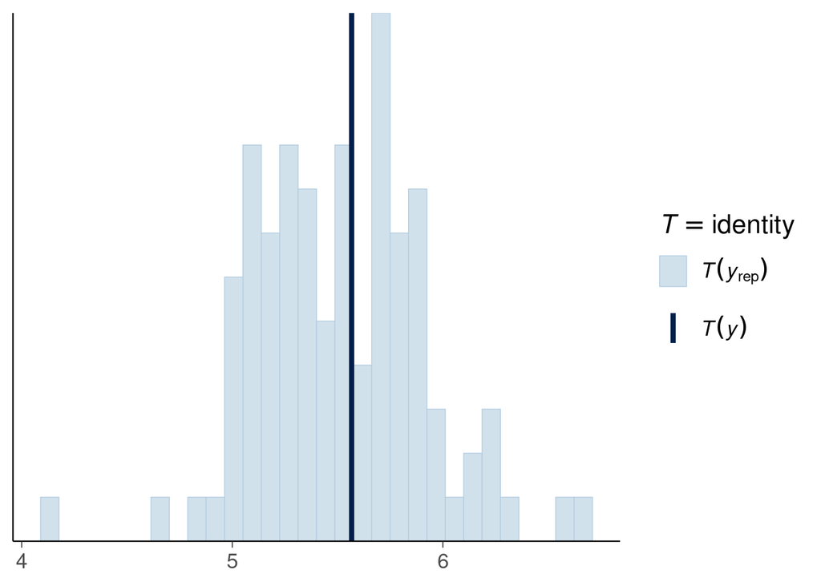

Figure 12

```r
yrep <- replicate(100, mean_switches(pred_log(bfit_4)))
ppc_stat(mean_switches(shock), matrix(yrep, nrow=length(yrep)), stat="identity")
```

## 8.6 Prior-likelihood sensitivity analysis

Using `priorsense` package for prior-likelihood sensitivity analysis shows that the data are informative and there is no need to think more about priors unless we do happen to have easily available strong prior information.

```r
powerscale_sensitivity(bfit_4, variable = variables(as_draws(bfit_4))[1:5]) |>
  tt() |>
  format_tt(num_fmt="decimal")
```

| variable | prior | likelihood | diagnosis |
| --- | --- | --- | --- |
| b_etaa_Intercept | 0.01 | 0.14 | - |
| b_etab_Intercept | 0 | 0.04 | - |
| sd_dog__etaa_Intercept | 0.01 | 0.37 | - |
| sd_dog__etab_Intercept | 0.01 | 0.63 | - |
| cor_dog__etaa_Intercept__etab_Intercept | 0 | 0.13 | - |

# 9 Comparing posterior predictions

We can compare the posterior predictions by overlaying them in the same plot. We see the biggest difference is visible in time $t=2$, but the differences are that small that given the small size of the data, there is no clear preference for either model.

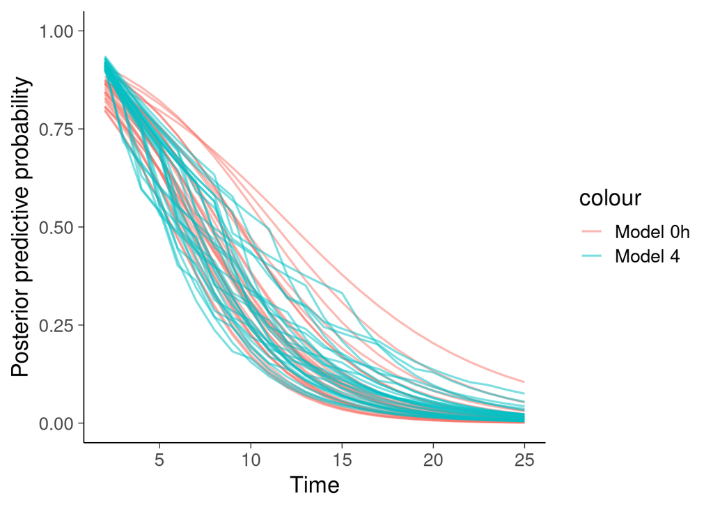

Figure 13

```r
dogs_df |>
  mutate(epred_0h = colMeans(posterior_epred(bfit_0h)),
         epred_4 = colMeans(posterior_epred(bfit_4))) |>
  ggplot(aes(x = time, group = dog)) +
  geom_line(aes(y = epred_0h, color = "Model 0h"), alpha = 0.5) +
  geom_line(aes(y = epred_4, color = "Model 4"), alpha = 0.5) +
  scale_y_continuous(lim = c(0, 1)) +
  labs(x="Time",y="Posterior predictive probability")
```

# 10 Leave-future-out cross-validation

Above we used LOO-CV which leaves out only one observation, but maybe we should examine the predictive performance only for the future observations. As the model fits are quite fast, we can do brute force leave.future-out cross-validation. We start with fitting the model with $t<5$ and predict the outcomes at $t=5$, and then fit with one more time point and repeat.

```r
ll_0h <- matrix(nrow=4000,ncol=0)
for (t in 5:25) {
  ll_0h <- cbind(ll_0h, rowSums(log_lik(update(bfit_0h, newdata = dplyr::filter(dogs_df, time < t)),
                                        newdata = dplyr::filter(dogs_df, time == t))))
}
ll_4 <- matrix(nrow=4000,ncol=0)
for (t in 5:25) {
  ll_4 <- cbind(ll_4, rowSums(log_lik(update(bfit_4, newdata = dplyr::filter(dogs_df, time < t)),
                                      newdata = dplyr::filter(dogs_df, time == t))))
}
```

There is no difference in predictive performance between the hierarchical logistic regression and hierarchical log model.

```r
loo_compare(list(bfit_0h=elpd(ll_0h),bfit_4=elpd(ll_4))) |>
  select(model, elpd_diff, se_diff, p_worse, diag_diff, diag_elpd) |>
  tt() |>
  format_tt(j=4, replace = "-")
```

| model | elpd_diff | se_diff | p_worse | diag_diff | diag_elpd |
| --- | --- | --- | --- | --- | --- |
| bfit_4 | 0 | 0 | - |  |  |
| bfit_0h | -2.1 | 3.3 | 0.74 | N < 100 |  |

# 11 Are the data informative on two parameters of 2-parameter log model?

One assumption about the 2-parameter log model is that if the posteriors of $a$ and $b$ are different, then the dogs learn a different amount from shocks and avoidances.

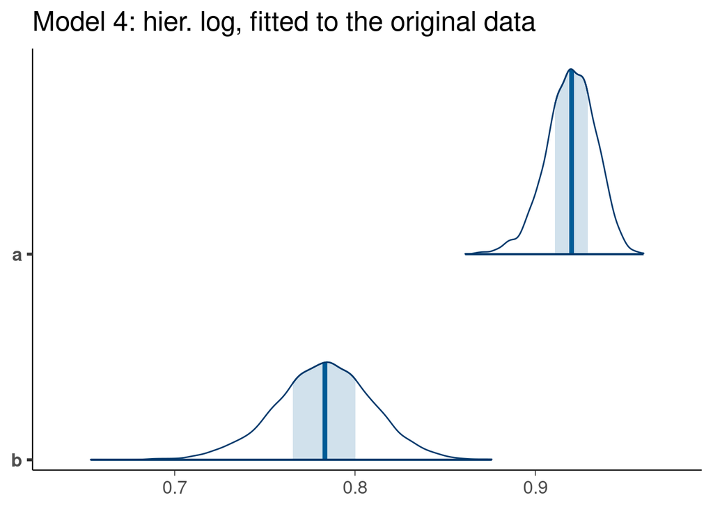

Figure 14

```r
as_draws_df(bfit_4) |>
  mutate(a = inv_logit(b_etaa_Intercept),
         b = inv_logit(b_etab_Intercept)) |>
  mcmc_areas(pars = c("a", "b")) +
  labs(title = "Model 4: hier. log, fitted to the original data")
```

The posteriors are clearly different, but is this due to different learning rate? We can test this by generating simulated data from the logistic regression model, which is noty making assumption about different learning rates from shocks and avoidances.

Generate shocks and avoidances using the simple logistic regression

```r
dogs_df_pred_0 <- dogs_df
pred_shock_0 <- matrix(c(rep(1, 30), posterior_predict(bfit_0, ndraws = 1) |> as.numeric()),
                       nrow = 30, ncol = 25)
dogs_df_pred_0$shock <- as.numeric(pred_shock_0[, 2:ncol(pred_shock_0)])
dogs_df_pred_0$prev_shock <- as.numeric(rowCumsums(pred_shock_0)[, 1:(ncol(pred_shock_0) - 1)])
dogs_df_pred_0$prev_avoid <- as.numeric(rowCumsums(1-pred_shock_0)[, 1:(ncol(pred_shock_0) - 1)])
bfit_4s <- brm(bf(shock ~ inv_logit(etaa)^prev_shock * inv_logit(etab)^prev_avoid,
                 mvbind(etaa, etab) ~ (1 |p| dog), nl = TRUE),
              family = bernoulli(link = "identity"),
              prior = c(prior(student_t(3, 0, 2.5), nlpar = "etaa"),
                        prior(student_t(3, 0, 2.5), nlpar = "etab")),
              data = dogs_df_pred_0, refresh=0)
```

The posterior for a and b are different!

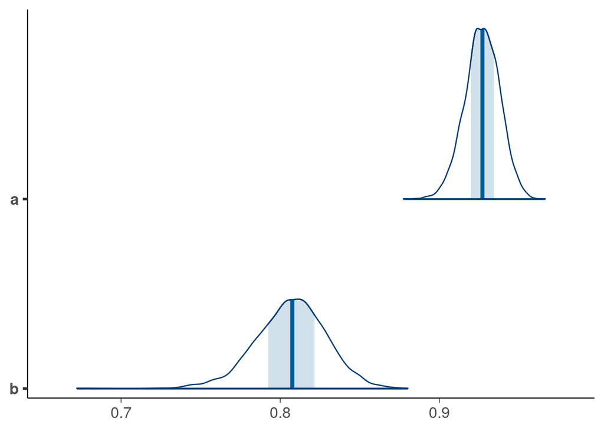

Figure 15

```r
as_draws_df(bfit_4s) |>
  mutate(a = inv_logit(b_etaa_Intercept),
         b = inv_logit(b_etab_Intercept)) |>
  mcmc_areas(pars = c("a", "b"))
```

Generate shocks and avoidances using the hierarchical logistic regression

```r
dogs_df_pred_0h <- dogs_df
pred_shock_0h <- matrix(c(rep(1, 30), posterior_predict(bfit_0h, ndraws = 1) |> as.numeric()),
                       nrow = 30, ncol = 25)
dogs_df_pred_0h$shock <- as.numeric(pred_shock_0h[, 2:ncol(pred_shock_0h)])
dogs_df_pred_0h$prev_shock <- as.numeric(rowCumsums(pred_shock_0h)[, 1:(ncol(pred_shock_0h) - 1)])
dogs_df_pred_0h$prev_avoid <- as.numeric(rowCumsums(1-pred_shock_0h)[, 1:(ncol(pred_shock_0h) - 1)])
bfit_4sh <- brm(bf(shock ~ inv_logit(etaa)^prev_shock * inv_logit(etab)^prev_avoid,
                mvbind(etaa, etab) ~ (1 |p| dog), nl=TRUE),
                family = bernoulli(link = "identity"),
                prior = c(prior(student_t(3, 0, 2.5), nlpar = "etaa"),
                          prior(student_t(3, 0, 2.5), nlpar = "etab")),
                data = dogs_df_pred_0h, refresh = 0)
```

The posterior for a and b are different!

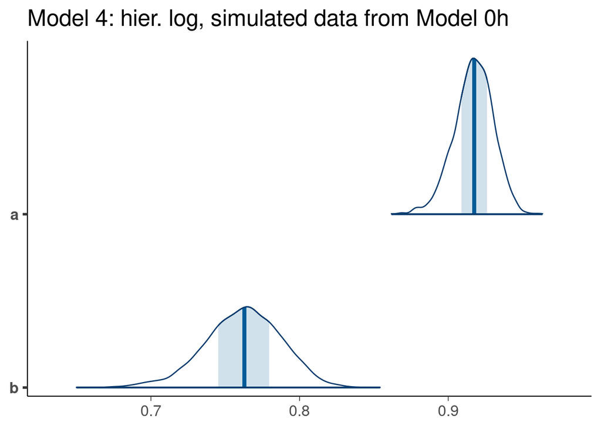

Figure 16

```r
as_draws_df(bfit_4sh) |>
  mutate(a = inv_logit(b_etaa_Intercept),
         b = inv_logit(b_etab_Intercept)) |>
  mcmc_areas(pars = c("a", "b")) +
  labs(title = "Model 4: hier. log, simulated data from Model 0h")
```

The two panels combined (Figure 21.12 in the book).

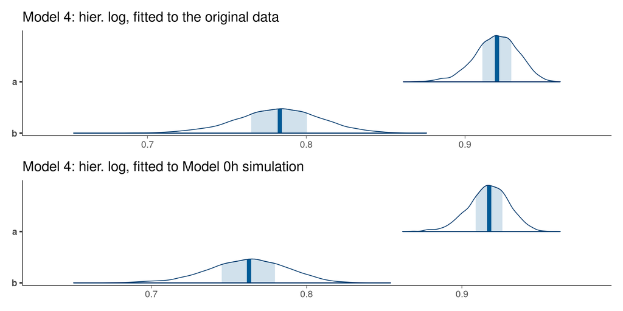

Figure 17

```r
areas_ab <- function(fit, title) {
  as_draws_df(fit) |>
    mutate(a = inv_logit(b_etaa_Intercept),
           b = inv_logit(b_etab_Intercept)) |>
    mcmc_areas(pars = c("a", "b")) +
    labs(title = title)
}
fig_simulfit <-
  areas_ab(bfit_4,   "Model 4: hier. log, fitted to the original data") /
  areas_ab(bfit_4sh, "Model 4: hier. log, fitted to Model 0h simulation")
fig_simulfit
```

# 12 Conclusion

Based on model comparison and various model checking diagnostics, data are not informative to make difference between hierarchical logistic regression model, 2-parameter log model, and hierarchical 2-parameter log model. Although the visual predictive checking in dogs example is historically interesting, it seems that it is not sufficient for making difference between some plausible models.

# References

Bush, R. R., and F. Mosteller. 1955. *Stochastic Models for Learning*. Wiley.

Dimitriadis, Timo, Tilmann Gneiting, and Alexander I. Jordan. 2021. “Stable Reliability Diagrams for Probabilistic Classifiers.” *Proceedings of the National Academy of Sciences* 118 (8): e2016191118.

Kallioinen, Noa, Topi Paananen, Paul-Christian Bürkner, and Aki Vehtari. 2023. “Detecting and Diagnosing Prior and Likelihood Sensitivity with Power-Scaling.” *Statistics and Computing* 34 (1): 57.

Kay, Matthew. 2023. *tidybayes: Tidy Data and Geoms for Bayesian Models*. https://doi.org/10.5281/zenodo.1308151.

Vehtari, Aki, Andrew Gelman, and Jonah Gabry. 2017. “Practical Bayesian Model Evaluation Using Leave-One-Out Cross-Validation and WAIC.” *Statistics and Computing* 27: 1413–32.

# Licenses

- Code © 2023–2025, Aki Vehtari and Andrew Gelman, licensed under BSD-3.
- Text © 2023–2025, Aki Vehtari and Andrew Gelman, licensed under CC-BY-NC 4.0.